# ProjectAnalysis

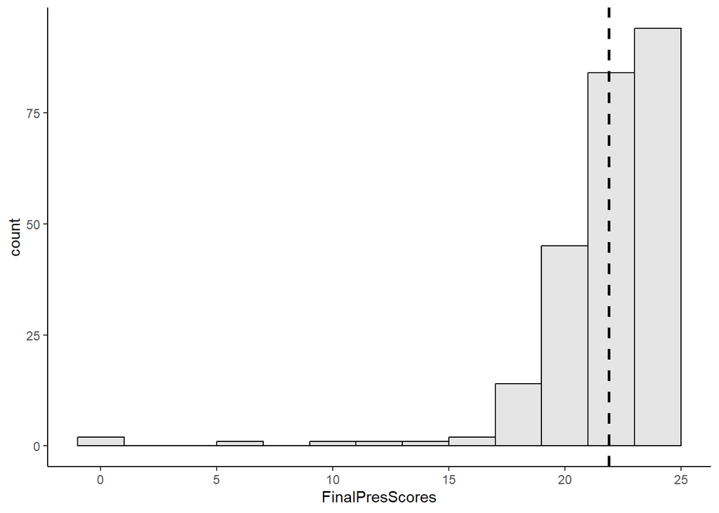

```r
#Merge in final presentation score info
All_summary <- merge(All_summary, pres_score, by = "Random_Number", all.x = TRUE)
# make Pres score a percentage
All_summary$pres_perc <- All_summary$FinalPresScores / 25

ggplot(All_summary, aes(x=FinalPresScores))+
  geom_histogram(binwidth=2, color = "black", fill = "grey90")+
  geom_vline(aes(xintercept=mean(FinalPresScores)),
            color="black", linetype="dashed", size=1)+
  theme_classic()
```

```r
# by section
All_summary %>%
  group_by(Sctn_Code) %>%
  summarize(mean_pres = mean(FinalPresScores, na.rm = TRUE), num = n())
```

```
## # A tibble: 4 × 3
##   Sctn_Code mean_pres   num
##   <chr>         <dbl> <int>
## 1 REC1           22.2    65
## 2 REC2           22.6    62
## 3 REC3           21.7    81
## 4 REC4           20.7    37
```

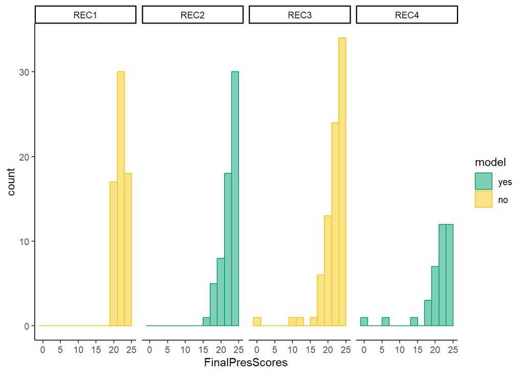

```r
# sec 1 and 2 have higher score, then 3, then 4
ggplot(All_summary, aes(x=FinalPresScores, ))+
  geom_histogram(binwidth=2, aes(color=model, fill = model), alpha = 0.5, position = "identity")+
  facet_grid(. ~ Sctn_Code)+
  scale_fill_manual(values = c("#009E73", "#F5C710"))+
  scale_color_manual(values = c("#009E73", "#F5C710"))+
  theme_classic()
```

```r
# by modelling
All_summary %>%
  group_by(model) %>%
  summarize(mean_pres = mean(FinalPresScores, na.rm = TRUE), num = n())
```

```
## # A tibble: 2 × 3
##   model mean_pres   num
##   <fct>     <dbl> <int>
## 1 yes        21.9    99
## 2 no         21.9   146
```

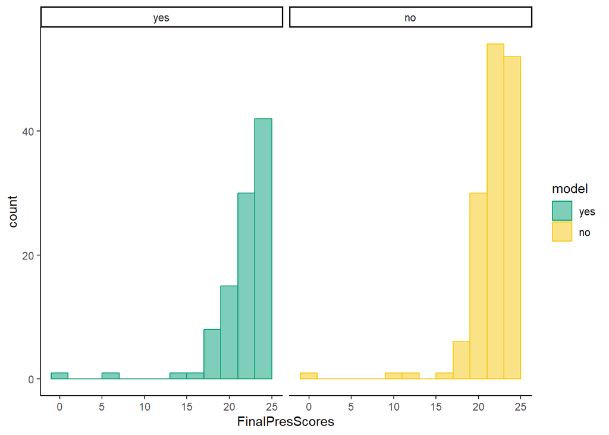

```r
# very similar
ggplot(All_summary, aes(x=FinalPresScores, ))+
  geom_histogram(binwidth=2, aes(color=model, fill = model), alpha = 0.5, position = "identity")+
  facet_grid(. ~ model)+
  scale_fill_manual(values = c("#009E73", "#F5C710"))+
  scale_color_manual(values = c("#009E73", "#F5C710"))+
  theme_classic()
```

To summarize, Sections 1 and 2 increased their science literacy scores but scored higher on the final presentation. Sections 3 and 4 also increased science literacy and had lower presentation scores. Sections 2 and 4 completed the modelling activity; students who completed the modeling activity had a slightly greater increase in science literacy than students who did not, but final presentation scores are very comparable.

## Statistics

Use a t-test to look for a difference in overall pre/post scores and for a difference in score changes between students who completed the modelling activity and those who did not.

I am interested in differences between sections that got the modelling activity and sections that did not get the modelling activity. Nested section within model should be a random effect because that is variation that I am not interested in analyzing. So I want to run models to predict pre_perc, post_perc, dif_perc, and pres_perc. Doing all as percentages for ease of comparison.

```r
# are the scores correlated?
cor(All_summary$post_perc, All_summary$pre_perc, method = "pearson")
```

```
## [1] 0.6291202
```

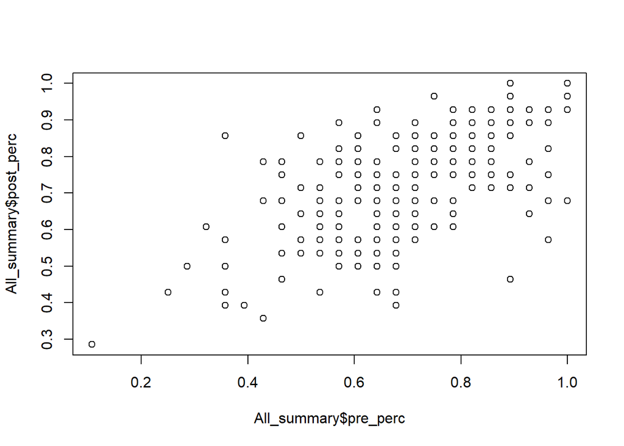

```r
plot(All_summary$pre_perc, All_summary$post_perc)
```

```r
cor(All_summary$post_perc, All_summary$dif_perc, method = "pearson")
```

```
## [1] 0.3127566
```

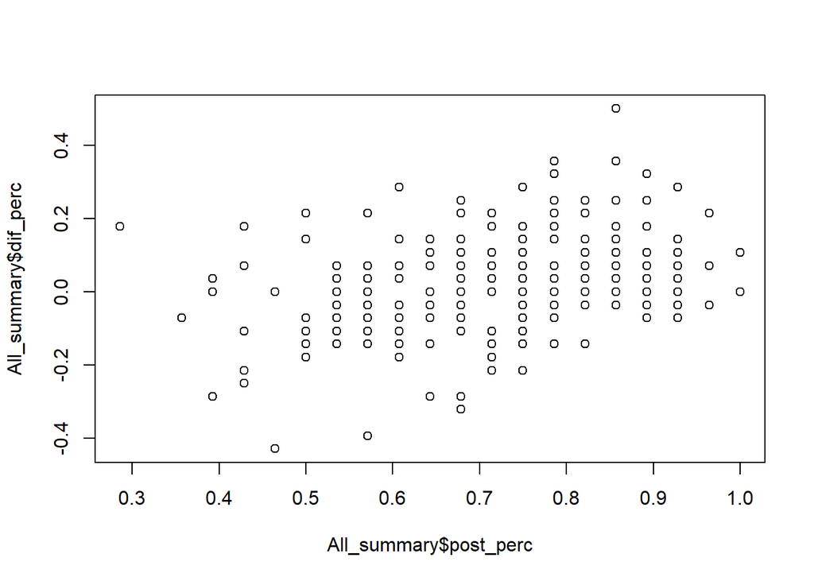

```r
plot(All_summary$post_perc, All_summary$dif_perc)
```

```r
cor(All_summary$dif_perc, All_summary$pre_perc, method = "pearson")
```

```
## [1] -0.5415515
```

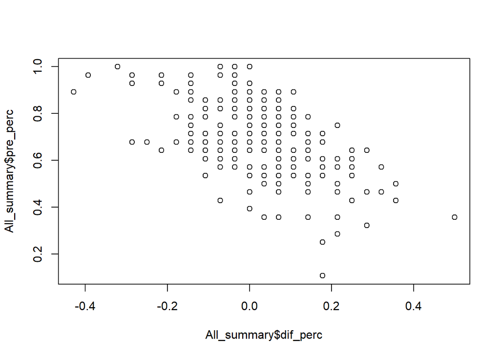

```r
plot(All_summary$dif_perc, All_summary$pre_perc)
```

```r
# SciLit + pres predicted by modelling
m_dif <- lmer(dif_perc ~ model + (1|Sctn_Code:model), data = All_summary)
```

```
## boundary (singular) fit: see help('isSingular')
```

```r
summary(m_dif)
```

```
## Linear mixed model fit by REML. t-tests use Satterthwaite's method [
## lmerModLmerTest]
## Formula: dif_perc ~ model + (1 | Sctn_Code:model)
##    Data: All_summary
##
## REML criterion at convergence: -291.8
##
## Scaled residuals:
##     Min      1Q  Median      3Q     Max
## -3.5176 -0.4990  0.0499  0.6503  3.6690
##
## Random effects:
##  Groups          Name        Variance Std.Dev.
##  Sctn_Code:model (Intercept) 0.00000  0.0000
##  Residual                    0.01694  0.1301
## Number of obs: 245, groups:  Sctn_Code:model, 4
##
## Fixed effects:
##               Estimate Std. Error         df t value Pr(>|t|)
## (Intercept)   0.029221   0.013080 243.000000   2.234   0.0264 *
## modelno      -0.006716   0.016944 243.000000  -0.396   0.6922
## ---
## Signif. codes:  0 '***' 0.001 '**' 0.01 '*' 0.05 '.' 0.1 ' ' 1
##
## Correlation of Fixed Effects:
##         (Intr)
## modelno -0.772
## optimizer (nloptwrap) convergence code: 0 (OK)
## boundary (singular) fit: see help('isSingular')
```

```r
# modelno had a negative effect (compared to modelyes) which is what I would expect if modelling had an impact even if small. Not a significant predictor of the difference in scores (t value = 0.396)

m_post <- lmer(post_perc ~ model + (1|Sctn_Code:model), data = All_summary)
```

```
## boundary (singular) fit: see help('isSingular')
```

```r
m_pre <- lmer(pre_perc ~ model + (1|Sctn_Code:model), data = All_summary)
```

```
## boundary (singular) fit: see help('isSingular')
```

```r
m_presentation <- lmer(pres_perc ~ model + (1|Sctn_Code:model), data = All_summary)
summary(m_presentation)
```

```
## Linear mixed model fit by REML. t-tests use Satterthwaite's method [
## lmerModLmerTest]
## Formula: pres_perc ~ model + (1 | Sctn_Code:model)
##    Data: All_summary
##
## REML criterion at convergence: -310.9
##
## Scaled residuals:
##     Min      1Q  Median      3Q     Max
## -6.9878 -0.3139  0.1808  0.5756  1.2149
##
## Random effects:
##  Groups          Name        Variance Std.Dev.
##  Sctn_Code:model (Intercept) 0.001149 0.0339
##  Residual                    0.015446 0.1243
## Number of obs: 245, groups:  Sctn_Code:model, 4
##
## Fixed effects:
##             Estimate Std. Error       df t value Pr(>|t|)
## (Intercept) 0.868268   0.027181 1.995302  31.944 0.000992 ***
## modelno     0.008768   0.037686 1.848671   0.233 0.839220
## ---
## Signif. codes:  0 '***' 0.001 '**' 0.01 '*' 0.05 '.' 0.1 ' ' 1
##
## Correlation of Fixed Effects:
##         (Intr)
## modelno -0.721
```

```r
# paired t test (same students, pre and post) to see if there is a difference between pre and post.
t.test(All_summary$pre_perc, All_summary$post_perc, paired = TRUE, alternative = "two.sided")
```

```
##
##  Paired t-test
##
## data:  All_summary$pre_perc and All_summary$post_perc
## t = -3.0383, df = 244, p-value = 0.002638
## alternative hypothesis: true mean difference is not equal to 0
## 95 percent confidence interval:
##  -0.041567799 -0.008869519
## sample estimates:
## mean difference
##     -0.02521866
```

```r
# t.test to see if model mattered on science literacy and final presentation scores
# p values are identical whether these use score numbers or percentages. This does not include section as a random effect.
stat_dif <- t.test(dif_score~model, data = All_summary)
stat_pre <- t.test(pre_score~model, data = All_summary)
stat_post <- t.test(post_score~model, data = All_summary)
stat_pres <-t.test(FinalPresScores~model, data = All_summary)

# just look at p vals, could make a table with all this later
stat_dif$p.value # no difference is sci lit change depending on treatment
```

```
## [1] 0.6984321
```

```r
stat_pre$p.value # no difference is sci lit pre score depending on treatment - this was expected b/c no treatment yet
```

```
## [1] 0.6011486
```

```r
stat_post$p.value # no difference is sci lit post score depending on treatment
```

```
## [1] 0.8165491
```

```r
stat_pres$p.value # no difference is final presentation score depending on treatment
```

```
## [1] 0.9796165
```

## Plot

Let’s make some plots to illlustrate the impact of the modelling activity of science literacy overall.

need to decide: boxplots on percentages or on scores? score (for difference at least) might be easier to interpret b/c clearly how well they are doing and more or fewer questions answered correctly. So might want to change stats to scores too instead of percentages?

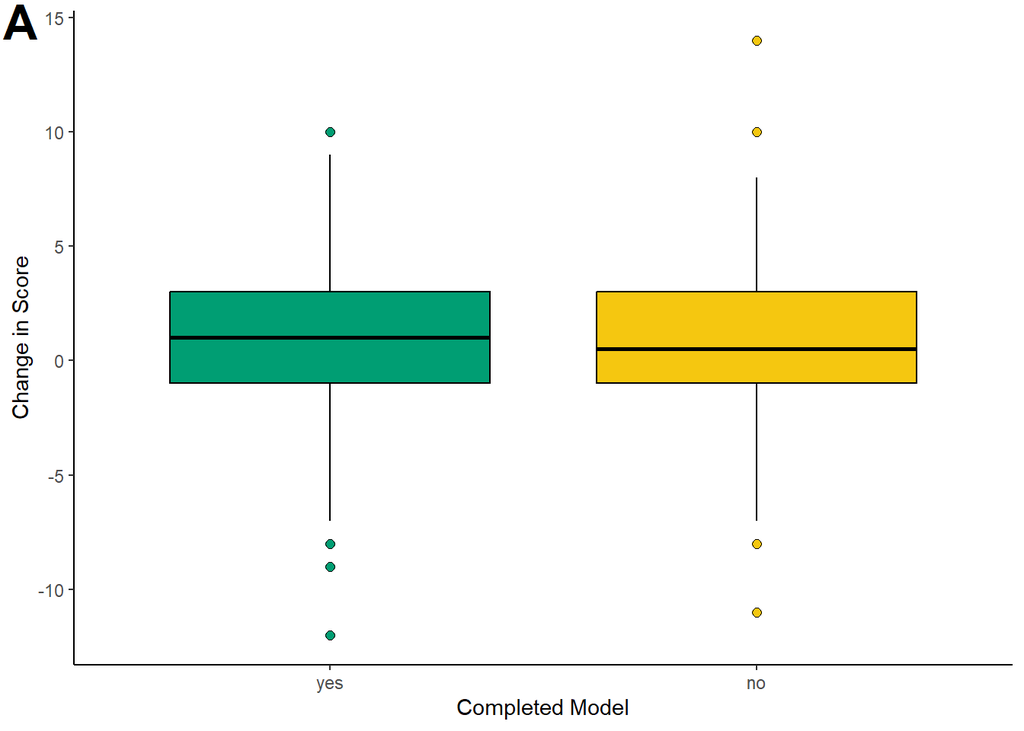

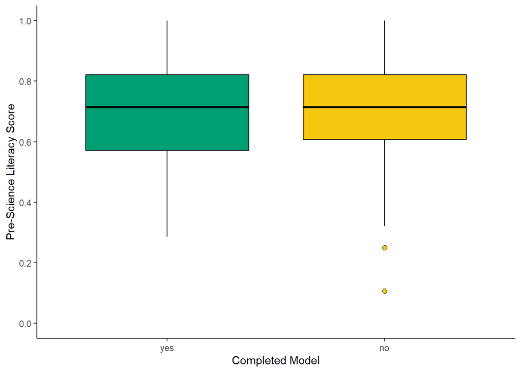

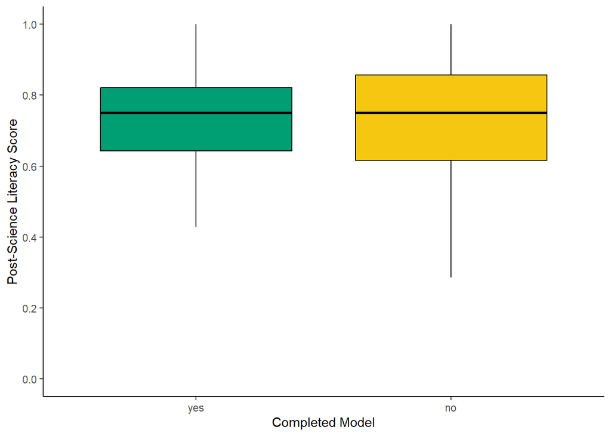

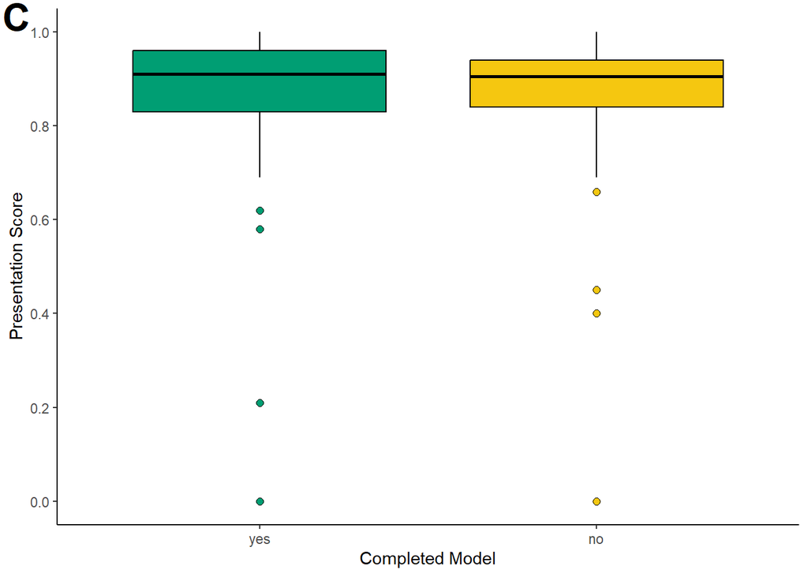

# Science and society

Recalculate scores by each of the 9 science literacy skills defined by Gormally et al. (2012). Questions were in different orders pre and post, so this did take some data wrangling.

Step one is to sort the post_all and the pre_all into the same order.

```r
# sort by question number, then random number, then answer
# Random num should be integer
pre_all$Random_Number <- as.integer(pre_all$Random_Number)
pre_all <- arrange(pre_all, `Q..`, `Random_Number`, `Answer`)

# same for post, but also only keep individuals in pre so dataframes same length
post_all <- post_all[post_all$Random_Number %in% pre_all$Random_Number, ]
post_all <- arrange(post_all, `Q..`, `Random_Number`,`Answer`)

# check is rows are the same
pre_all[1000, ]
```

```
##      Attempt..       Attempt.Start         Attempt.End Section.. Q.. Q.Type
## 1000         1 2023-02-03 09:41:00 2023-02-03 10:01:00        NA   2     MC
##      Q.Title                                                 Q.Text Bonus.
## 1000         Which of the following is a valid scientific argument?  FALSE
##      Difficulty
## 1000          1
##                                                                                                                                                                                                                                                                                  Answer
## 1000 A strain of mice was genetically engineered to lack a certain gene, and the mice were unable to reproduce.\xa0 Introduction of the gene back into the mutant mice restored their ability to reproduce.\xa0 These facts indicate that the gene is essential for mouse reproduction.
##      Answer.Match Score Out.Of X19 X20 Random_Number Crse_Code Sctn_Code
## 1000      Checked     1      1  NA  NA           526       171      REC4
##      Sctn_Id_Code Time
## 1000    223210822   20
```

```r
post_all[1000, ]
```

```
##      Attempt..       Attempt.Start         Attempt.End Section.. Q.. Q.Type
## 1000         1 2023-04-27 11:54:00 2023-04-27 12:08:00        NA   2     MC
##      Q.Title                                                 Q.Text Bonus.
## 1000         Which of the following is a valid scientific argument?  FALSE
##      Difficulty
## 1000          1
##                                                                                                                                                                                                                                                                                  Answer
## 1000 A strain of mice was genetically engineered to lack a certain gene, and the mice were unable to reproduce.\xa0 Introduction of the gene back into the mutant mice restored their ability to reproduce.\xa0 These facts indicate that the gene is essential for mouse reproduction.
##      Answer.Match Score Out.Of X19 X20 Random_Number Crse_Code Sctn_Code
## 1000      Checked     1      1  NA  NA           526       171      REC4
##      Sctn_Id_Code Time
## 1000    223210822   14
```

```r
pre_all[10006, ]
```

```
##       Attempt..       Attempt.Start         Attempt.End Section.. Q.. Q.Type
## 10006         1 2023-02-06 09:54:00 2023-02-06 10:31:00        NA  11     MC
##       Q.Title
## 10006
##                                                                                                                                                                                                                                                                                                          …
## 10006 Background for this question: Your interest is piqued by a story about human pheromones on the news. A Google search leads you to the following website:  For this website (Eros Foundation), which of the following characteristics is most important in your confidence that the resource is accu…
##       Bonus. Difficulty
## 10006  FALSE          1
##                                                                                             Answer
## 10006 The resource may not be accurate, because the purpose of the site is to advertise a product.
##       Answer.Match Score Out.Of X19 X20 Random_Number Crse_Code Sctn_Code
## 10006    UnChecked     0      1  NA  NA           751       171      REC1
##       Sctn_Id_Code Time
## 10006    223210820   37
```

```r
post_all[10006, ]
```

```
##       Attempt..       Attempt.Start         Attempt.End Section.. Q.. Q.Type
## 10006         1 2023-04-24 19:35:00 2023-04-24 20:26:00        NA  11     MC
##       Q.Title
## 10006
##                                                                                                                                                                                                                                                                                                          …
## 10006 Background for this question: Your interest is piqued by a story about human pheromones on the news. A Google search leads you to the following website:  For this website (Eros Foundation), which of the following characteristics is most important in your confidence that the resource is accu…
##       Bonus. Difficulty
## 10006  FALSE          1
##                                                                                             Answer
## 10006 The resource may not be accurate, because the purpose of the site is to advertise a product.
##       Answer.Match Score Out.Of X19 X20 Random_Number Crse_Code Sctn_Code
## 10006      Checked     1      1  NA  NA           751       171      REC1
##       Sctn_Id_Code Time
## 10006    223210820   51
```

```r
# add model column to both
pre_all$model <- "no"
pre_all[pre_all$Sctn_Code %in% c("REC2", "REC4"), "model"] <- "yes"

post_all$model <- "no"
post_all[post_all$Sctn_Code %in% c("REC2", "REC4"), "model"] <- "yes"
```

Now that everything is sorted the same, I want to separate into 9 dataframes depending on the question number. but keeping in mind that everything is shifted up one (reference says Q1, is Q2 in this dataframe)

Skill 1 - Identify a valid scientific argument - reference: 1, 8, 11 -> this dataframe: 2, 9, 12 Only writting down this dataframe references for the rest

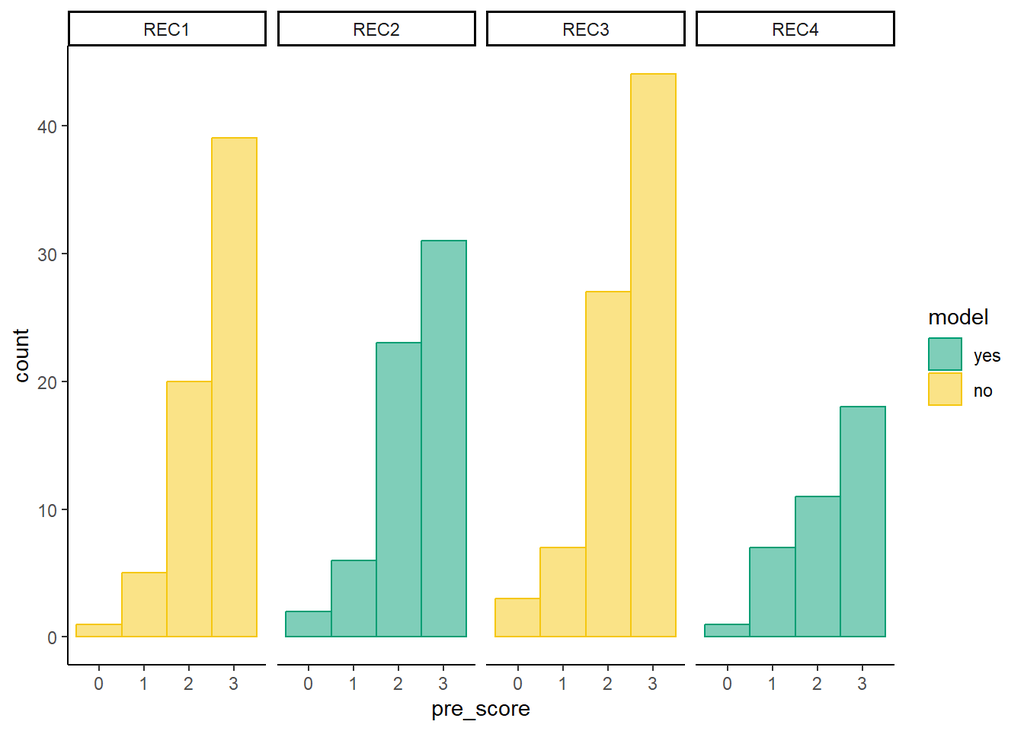

```r
# keep only the questions I need and only the checked row for each students b/c that will have the score column so I don't need to score by hand.
pre_s1 <- pre_all[pre_all$`Q..` %in% c(2, 9, 12) & pre_all$`Answer.Match` == "Checked", ]

# now group by random number and calculate the score for skill 1
sum_pre_s1 <- pre_s1 %>%
  group_by(Random_Number) %>%
  summarize(pre_score = sum(Score), Sctn_Code = unique(Sctn_Code), model = unique(model))
# add percentage column
sum_pre_s1$pre_perc <- sum_pre_s1$pre_score / 3

# now for post
post_s1 <- post_all[post_all$`Q..` %in% c(2, 9, 12) & post_all$`Answer.Match` == "Checked", ]

# now group by random number and calculate the score for skill 1
sum_post_s1 <- post_s1 %>%
  group_by(Random_Number) %>%
  summarize(post_score = sum(Score), Sctn_Code = unique(Sctn_Code), model = unique(model))
# add percentage column
sum_post_s1$post_perc <- sum_post_s1$post_score / 3

# merge those together
sum_s1 <- merge(sum_pre_s1, sum_post_s1, by = c("Random_Number", "Sctn_Code", "model"))
sum_s1$model <- factor(sum_s1$model, levels = c("yes", "no"))

ggplot(sum_s1, aes(x=pre_score ))+
  geom_histogram(binwidth=1, aes(color=model, fill = model), alpha = 0.5, position = "identity")+
  facet_grid(. ~ Sctn_Code)+
  scale_fill_manual(values = c("#009E73", "#F5C710"))+
  scale_color_manual(values = c("#009E73", "#F5C710"))+
  theme_classic()
```

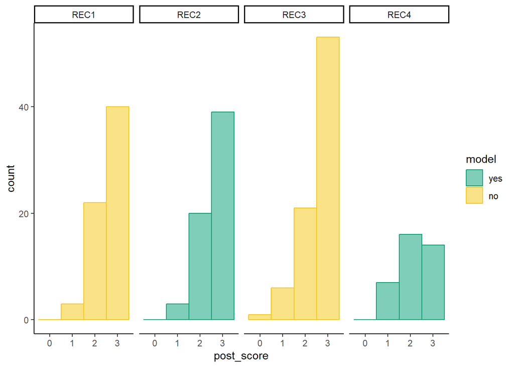

```r
ggplot(sum_s1, aes(x=post_score ))+
  geom_histogram(binwidth=1, aes(color=model, fill = model), alpha = 0.5, position = "identity")+
  facet_grid(. ~ Sctn_Code)+
  scale_fill_manual(values = c("#009E73", "#F5C710"))+
  scale_color_manual(values = c("#009E73", "#F5C710"))+
  theme_classic()
```

```r
# calculate the difference in points
sum_s1$dif_score <- sum_s1$post_score - sum_s1$pre_score

# quick check of what things look like by modelling and section
sum_s1 %>%
  group_by(Sctn_Code) %>%
  summarize(mean_pre = mean(pre_perc),
            mean_post = mean(post_perc),
            mean_dif = mean(dif_score))
```

```
## # A tibble: 4 × 4
##   Sctn_Code mean_pre mean_post mean_dif
##   <chr>        <dbl>     <dbl>    <dbl>
## 1 REC1         0.831     0.856   0.0769
## 2 REC2         0.780     0.860   0.242
## 3 REC3         0.794     0.852   0.173
## 4 REC4         0.748     0.730  -0.0541
```

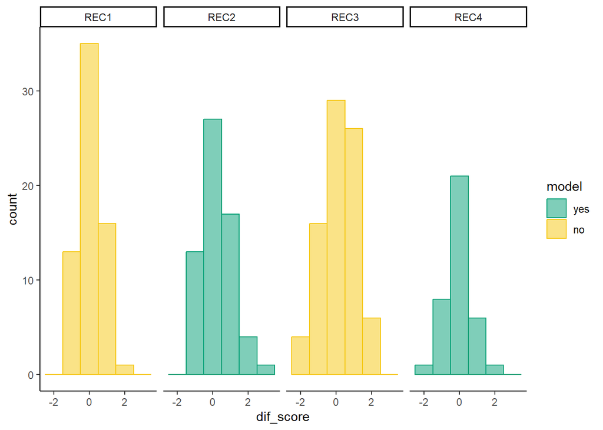

```r
# 1 best in pre, 4 worst in post, 4 only one with negative post but basically zero, 2 best increase
ggplot(sum_s1, aes(x=dif_score ))+
  geom_histogram(binwidth=1, aes(color=model, fill = model), alpha = 0.5, position = "identity")+
  facet_grid(. ~ Sctn_Code)+
  scale_fill_manual(values = c("#009E73", "#F5C710"))+
  scale_color_manual(values = c("#009E73", "#F5C710"))+
  theme_classic()
```

```r
# by modelling
sum_s1 %>%
  group_by(model) %>%
  summarize(mean_pre = mean(pre_perc),
            mean_post = mean(post_perc),
            mean_dif = mean(dif_score))
```

```
## # A tibble: 2 × 4
##   model mean_pre mean_post mean_dif
##   <fct>    <dbl>     <dbl>    <dbl>
## 1 yes      0.768     0.811    0.131
## 2 no       0.811     0.854    0.130
```

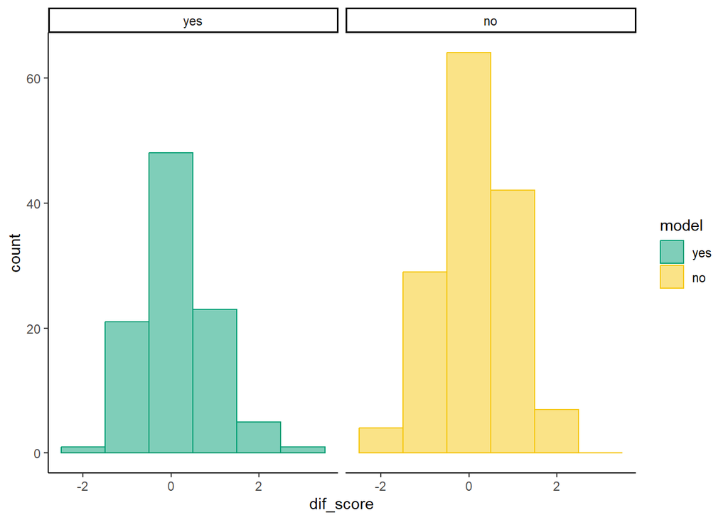

```r
# yes had lower pre and post but mean dif is exactly the same

ggplot(sum_s1, aes(x=dif_score ))+
  geom_histogram(binwidth=1, aes(color=model, fill = model), alpha = 0.5, position = "identity")+
  facet_grid(. ~ model)+
  scale_fill_manual(values = c("#009E73", "#F5C710"))+
  scale_color_manual(values = c("#009E73", "#F5C710"))+
  theme_classic()
```

```r
# do t test to see if difference in scores pre/post matters by modelling
dif_s1 <- t.test(dif_score~model, data = sum_s1)

# add skill column
sum_s1$skill <- 1
```

Skill 2 - Conduct an effective literature search of sources and distinguish between types of sources: 11, 13, 18, 23, 27

```r
# keep only the questions I need and only the checked row for each students b/c that will have the score column so I don't need to score by hand.
pre_s2 <- pre_all[pre_all$`Q..` %in% c(11, 13, 18, 23, 27) & pre_all$`Answer.Match` == "Checked", ]

# now group by random number and calculate the score for skill 2
sum_pre_s2 <- pre_s2 %>%
  group_by(Random_Number) %>%
  summarize(pre_score = sum(Score), Sctn_Code = unique(Sctn_Code), model = unique(model))
# add percentage column
sum_pre_s2$pre_perc <- sum_pre_s2$pre_score / 5

# now for post
post_s2 <- post_all[post_all$`Q..` %in% c(11, 13, 18, 23, 27) & post_all$`Answer.Match` == "Checked", ]

# now group by random number and calculate the score for skill 2
sum_post_s2 <- post_s2 %>%
  group_by(Random_Number) %>%
  summarize(post_score = sum(Score), Sctn_Code = unique(Sctn_Code), model = unique(model))
# add percentage column
sum_post_s2$post_perc <- sum_post_s2$post_score / 5

# merge those together
sum_s2 <- merge(sum_pre_s2, sum_post_s2, by = c("Random_Number", "Sctn_Code", "model"))

# calculate the difference in points
sum_s2$dif_score <- sum_s2$post_score - sum_s2$pre_score

# quick check of what things look like by modelling and section
sum_s2 %>%
  group_by(Sctn_Code) %>%
  summarize(mean_pre = mean(pre_perc),
            mean_post = mean(post_perc),
            mean_dif = mean(dif_score))
```

```
## # A tibble: 4 × 4
##   Sctn_Code mean_pre mean_post mean_dif
##   <chr>        <dbl>     <dbl>    <dbl>
## 1 REC1         0.637     0.658   0.108
## 2 REC2         0.613     0.674   0.306
## 3 REC3         0.654     0.657   0.0123
## 4 REC4         0.654     0.708   0.270
```

```r
# all same pre. 2 and 4 had best increase
# by modelling
sum_s2 %>%
  group_by(model) %>%
  summarize(mean_pre = mean(pre_perc),
            mean_post = mean(post_perc),
            mean_dif = mean(dif_score))
```

```
## # A tibble: 2 × 4
##   model mean_pre mean_post mean_dif
##   <chr>    <dbl>     <dbl>    <dbl>
## 1 no       0.647     0.658   0.0548
## 2 yes      0.628     0.687   0.293
```

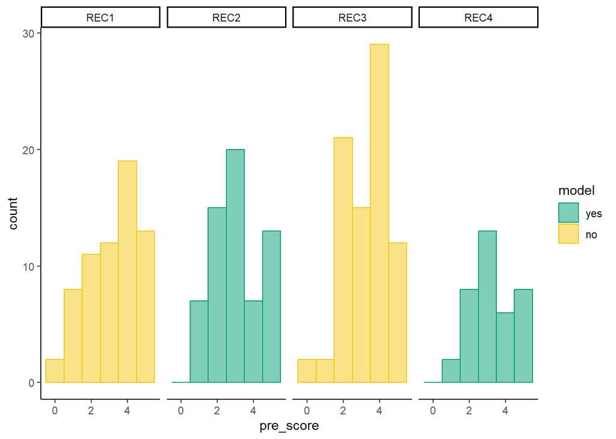

```r
# yes had better increase! but this isnt' something I expected the modelling activity to help with

# do t test to see if difference in scores pre/post matters by modelling
dif_s2 <- t.test(dif_score~model, data = sum_s2)

# add skill column
sum_s2$skill <- 2

sum_s2$model <- factor(sum_s2$model, levels = c("yes", "no"))

ggplot(sum_s2, aes(x=pre_score ))+
  geom_histogram(binwidth=1, aes(color=model, fill = model), alpha = 0.5, position = "identity")+
  facet_grid(. ~ Sctn_Code)+
  scale_fill_manual(values = c("#009E73", "#F5C710"))+
  scale_color_manual(values = c("#009E73", "#F5C710"))+
  theme_classic()
```

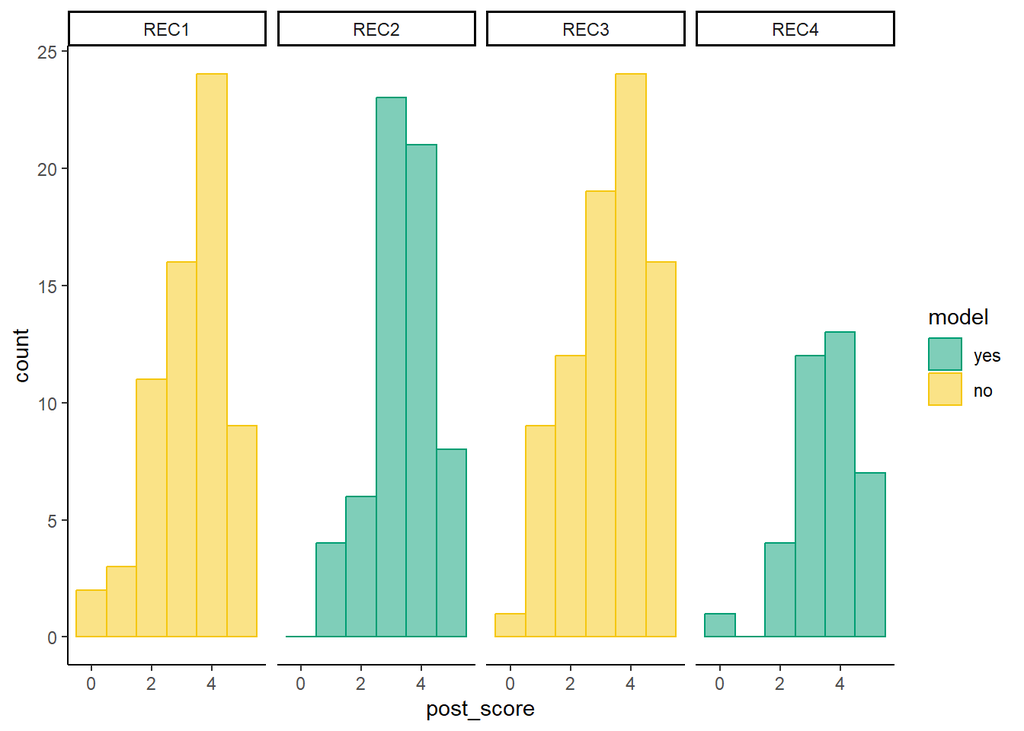

```r
ggplot(sum_s2, aes(x=post_score ))+
  geom_histogram(binwidth=1, aes(color=model, fill = model), alpha = 0.5, position = "identity")+
  facet_grid(. ~ Sctn_Code)+
  scale_fill_manual(values = c("#009E73", "#F5C710"))+
  scale_color_manual(values = c("#009E73", "#F5C710"))+
  theme_classic()
```